# Homework #2 - Statistical Methods in Data Science II & Lab

Barboni Alessio, 2027647

15/06/2022

# Exercise 1

## 1A)

```r
# Import data
df <- list(x = c(1.0, 1.5, 1.5, 1.5, 2.5, 4.0, 5.0, 5.0, 7.0,
                     8.0,  8.5,  9.0,  9.5, 9.5,  10.0, 12.0, 12.0, 13.0,
                     13.0, 14.5, 15.5, 15.5, 16.5, 17.0, 22.5, 29.0, 31.5),
           Y = c(1.80, 1.85, 1.87, 1.77, 2.02, 2.27, 2.15, 2.26, 2.47,
                     2.19, 2.26, 2.40, 2.39, 2.41, 2.50, 2.32, 2.32, 2.43,
                     2.47, 2.56, 2.65, 2.47, 2.64, 2.56, 2.70, 2.72, 2.57),
           N = 27)
```

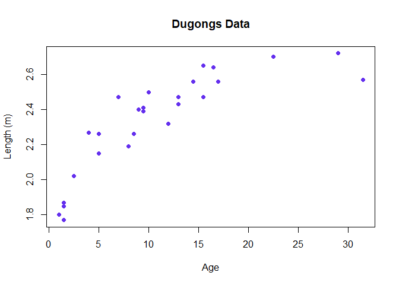

The statistical model for dealing with this data is illustrated in Carlin and Gelfand (1991), and consists in the following non-linear regression model:

$y_i \sim \mathbb{N}(\mu_i, \tau^2), \;\;\; \mu_i=f(x_i)=\alpha-\beta \gamma^{x_i}$

Where: $\: \alpha \sim \mathbb{N}(0, \sigma_{\alpha}^2), \;\; \beta \sim \mathbb{N}(0, \sigma_{\beta}^2) \:$ with $\: \alpha, \beta \in (1,\infty)$

$\gamma \sim Unif(0,1)$, with $\: \gamma \in (0,1) \:$ and $\: \tau^2 \sim InvGamma(a,b) \:$ with $\: \tau^2 \in (0,\infty)$

This model will be defined later using the *JAGS syntax* in a *txt* file named “*dugong_model.txt*”, containing the following lines:

```r
model   {
        for( i in 1:N ) {
            Y[i] ~ dnorm(mu[i], precision)
            mu[i] <- alpha - beta * pow(gamma,x[i])
        }
        alpha ~ dnorm(0.0, 1.0E-3)I(1.0,)
        beta ~ dnorm(0.0, 1.0E-3)I(1.0,)
        gamma ~ dbeta(1.0, 1.0)
        precision ~ dgamma(2.5, 0.1125)
    }
```

Since the *Inverse Gamma distribution* is not available in JAGS (cf. *JAGS-user-manual* pg. 34), the *variance* $\tau^2$ has been re-parametrized with the *precision*, defined as $\frac{1}{\tau^2}$, that is distributed as a *Gamma* with the same parameters.

### 1B)

**Likelihood function** derivation:

$L_{\mathbf{y}}(\boldsymbol{\mu}, \tau^2) := \prod\limits_{i=1}^{n} f(y_i|\mu_i, \tau^2) = \prod\limits_{i=1}^{n} \frac{1}{\sqrt{2\pi\tau^2}} \, e^{-\frac{1}{2\tau^2}(y_i-\mu_i)^2} \small{I_{(0,\infty)}(\tau^2)} \propto \\ \propto \prod\limits_{i=1}^{n}\tau^{-1} \, e^{-\frac{1}{2\tau^2}(y_i-\alpha+\beta \gamma^{x_i})^2} \; \small{I_{(1,\infty)}(\alpha) \; I_{(1,\infty)}(\beta) \; \small{I_{(0,1)}(\gamma) \; I_{(0,\infty)}(\tau^2)}} = \\ = \tau^{-n} \, e^{-\frac{1}{2\tau^2} \sum\limits_{i=1}^{n}(y_i-\alpha+\beta\gamma^{x_i})^2} \; \small{I_{(1,\infty)}(\alpha) \; I_{(1,\infty)}(\beta) \; I_{(0,1)}(\gamma) \; I_{(0,\infty)}(\tau^2)}$

### 1C)

**Joint prior distribution** of the parameters:

$\pi(\alpha, \beta, \gamma, \tau^2) \stackrel{ind}{=} \pi(\alpha)\pi(\beta)\pi(\gamma)\pi(\tau^2) = \\ = \frac{1}{\sqrt{2\pi\sigma_{\alpha}^2}} \; e^{-\frac{1}{2\sigma_{\alpha}^2}\alpha^2}\frac{1}{\sqrt{2\pi\sigma_{\beta}^2}} \; e^{-\frac{1}{2\sigma_{\beta}^2}\beta^2} \frac{1}{1-0} \; \frac{b^a}{(a-1)!} \; \tau^{2(-a-1)} \; e^{-\frac{b}{\tau^2}} \; \small{I_{(1,\infty)}(\alpha) \; I_{(1,\infty)}(\beta) \; I_{(0,\infty)}(\tau^2)}$

The choice of the hyperparameters of the prior distribution could even be arbitrary, since with large sample sizes the role played by the prior becomes more and more negligible. However, to have an idea about their appropriate scales academic research could be looked up, or more simply the dataset provided (as an approximation!).

```r
#Dataset summaries
emp.mean <- round(mean(df$Y),3)
emp.var <- round(var(df$Y),3)
cat("Emp. Mean: ", emp.mean,", ", "Emp. Variance: ", emp.var, sep="")
```

```
## Emp. Mean: 2.334, Emp. Variance: 0.075
```

- Inverse Gamma hyperparameters: $\tau^2$ is the actual variance of the response $y_i$, thus the hyperparameters of its distribution can be set in such a way to have the mean of the inverse gamma (approximately) equal to the empirical variance of the $y_i$’s of the sample dataset (i.e., 0.075). The former is defined as $\frac{b}{a-1}$, hence a system of one equation and two unknowns is set. Of course, since the dataset has only 27 observations, it is better to have a prior that it’s not too concentrated around that value, but rather flat. Below the result obtained by trial and error:

```r
library(invgamma)
#arbitrary choice for a
a <- 2.5
#solve for b
b <- a*emp.var - emp.var
cat("a: ",a,", ","b: ", b, ", ","var: ",b/(a-1), sep="")
```

```
## a: 2.5, b: 0.1125, var: 0.075
```

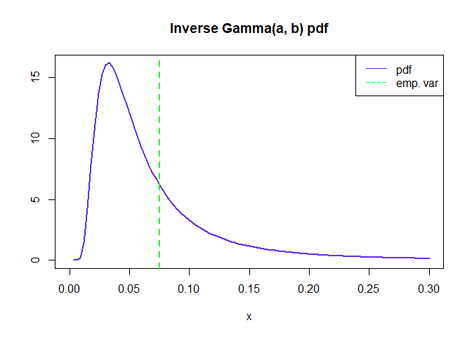

### 1D)

**Full-Conditional for** $\boldsymbol{\alpha}$: $\;\; \pi(\alpha|\beta, \gamma, \tau^2, \mathbf{y}) \propto \pi( \alpha) L_{\mathbf{y}}(\alpha, \beta, \gamma,\tau^2) \propto \\$ $\propto \frac{1}{\sqrt{2\pi\sigma_{\alpha}^2}} \; e^{-\frac{1}{2\sigma_{\alpha}^2}\alpha^2} \tau^{-n} \, e^{-\frac{1}{2\tau^2} \sum\limits_{i=1}^{n}(y_i-\alpha+\beta\gamma^{x_i})^2} \; \small{I_{(1,\infty)}(\alpha) \; I_{(1,\infty)}(\beta) \; I_{(0,1)}(\gamma) \; I_{(0,\infty)}(\tau^2)} \propto \\ \propto e^{-\frac{1}{2\sigma_{\alpha}^2}\alpha^2 -\frac{1}{2\tau^2} \sum\limits_{i=1}^{n}(y_i-\alpha+\beta\gamma^{x_i})^2} \; \small{I_{(1,\infty)}(\alpha) \; I_{(1,\infty)}(\beta) \; I_{(0,1)}(\gamma) \; I_{(0,\infty)}(\tau^2)} \propto \\ \propto e^{-\frac{1}{2}\alpha^2(\frac{n}{\tau^2}+\frac{1}{\sigma_{\alpha}^2})+\frac{\alpha}{\tau^2} \sum\limits_{i=1}^{n}(y_i+\beta\gamma^{x_i})} \; \small{I_{(1,\infty)}(\alpha) \; I_{(1,\infty)}(\beta) \; I_{(0,1)}(\gamma) \; I_{(0,\infty)}(\tau^2)}$

**Full-Conditional for** $\boldsymbol{\beta}$: $\;\; \pi(\beta|\alpha, \gamma, \tau^2, \mathbf{y}) \propto \pi(\beta) L_{\mathbf{y}}(\alpha, \beta, \gamma,\tau^2) \propto \\$ $\frac{1}{\sqrt{2\pi\sigma_{\beta}^2}} \; e^{-\frac{1}{2\sigma_{\beta}^2}\beta^2} \tau^{-n} \, e^{-\frac{1}{2\tau^2} \sum\limits_{i=1}^{n}(y_i-\alpha+\beta\gamma^{x_i})^2} \; \small{I_{(1,\infty)}(\alpha) \; I_{(1,\infty)}(\beta) \; I_{(0,1)}(\gamma) \; I_{(0,\infty)}(\tau^2)} \propto \\ \propto e^{-\frac{1}{2\sigma_{\beta}^2}\beta^2 -\frac{1}{2\tau^2} \sum\limits_{i=1}^{n}(y_i-\alpha+\beta\gamma^{x_i})^2} \; \small{I_{(1,\infty)}(\alpha) \; I_{(1,\infty)}(\beta) \; I_{(0,1)}(\gamma) \; I_{(0,\infty)}(\tau^2)} \propto \\ \propto e^{-\frac{1}{2\sigma_{\beta}^2}\beta^2-\frac{1}{2\tau^2} \sum\limits_{i=1}^{n}[\beta^{2}\gamma^{2x_i}+2 \, \beta\gamma^{x_i}(y_{i}-\alpha)]} \; \small{I_{(1,\infty)}(\alpha) \; I_{(1,\infty)}(\beta) \; I_{(0,1)}(\gamma) \; I_{(0,\infty)}(\tau^2)}$

**Full-Conditional for** $\boldsymbol{\gamma}$: $\;\; \pi(\gamma|\alpha, \beta, \tau^2, \mathbf{y}) \propto \pi(\gamma) L_{\mathbf{y}}(\alpha, \beta, \gamma,\tau^2) \propto \\$ $\propto \tau^{-n} \, e^{-\frac{1}{2\tau^2} \sum\limits_{i=1}^{n}(y_i-\alpha+\beta\gamma^{x_i})^2} \; \small{I_{(1,\infty)}(\alpha) \; I_{(1,\infty)}(\beta) \; I_{(0,1)}(\gamma) \; I_{(0,\infty)}(\tau^2)} \propto \\ \propto e^{-\frac{1}{2\tau^2} \sum\limits_{i=1}^{n}[\beta^{2}\gamma^{2x_i}+2 \, \beta\gamma^{x_i}(y_{i}-\alpha)]} \; \small{I_{(1,\infty)}(\alpha) \; I_{(1,\infty)}(\beta) \; I_{(0,1)}(\gamma) \; I_{(0,\infty)}(\tau^2)}$

**Full-Conditional for** $\boldsymbol{\tau^2}$: $\;\; \pi(\tau^2|\alpha, \beta, \gamma, \mathbf{y}) \propto \pi(\tau^2) L_{\mathbf{y}}(\alpha, \beta, \gamma,\tau^2) \propto \\$ $\propto \tau^{2(-a-1)} \; e^{-\frac{b}{\tau^2}} \tau^{-n} \, e^{-\frac{1}{2\tau^2} \sum\limits_{i=1}^{n}(y_i-\alpha+\beta\gamma^{x_i})^2} \; \small{I_{(1,\infty)}(\alpha) \; I_{(1,\infty)}(\beta) \; I_{(0,1)}(\gamma) \; I_{(0,\infty)}(\tau^2)} \propto \\ \propto \tau^{2(-a-1)-n} \; e^{-\frac{b}{\tau^2} -\frac{1}{2\tau^2} \sum\limits_{i=1}^{n}(y_i-\alpha+\beta\gamma^{x_i})^2} \; \small{I_{(1,\infty)}(\alpha) \; I_{(1,\infty)}(\beta) \; I_{(0,1)}(\gamma) \; I_{(0,\infty)}(\tau^2)}$

### 1E)

In order to sample easily in R from the four full-conditionals, (up to some proportionality constants) it can be noticed that:

- $\alpha$’s full conditional resembles a $\mathbb{N}(\mu=\mu_{\alpha'},\; \sigma^2= \tau_{\alpha'}^2)$, in fact:

$\pi(\alpha|\beta, \gamma, \tau^2, \mathbf{y}) \propto e^{-\frac{1}{2}\alpha^2(\frac{n}{\tau^2}+\frac{1}{\sigma_{\alpha}^2})+\frac{\alpha}{\tau^2}\sum\limits_{i=1}^{n}(y_i+\beta\gamma^{x_i})} = e^{-\frac{1}{2}((\frac{n}{\tau^2}+\frac{1}{\sigma_{\alpha}^2})\alpha^2-(\frac{2}{\tau^2} \sum\limits_{i=1}^{n}(y_i+\beta\gamma^{x_i}))\alpha)} = \\ = e^{-\frac{1}{2}(\frac{n}{\tau^2}+\frac{1}{\sigma_{\alpha}^2})\left(\alpha^2-\frac{\frac{2}{\tau^2} \sum\limits_{i=1}^{n}(y_i+\beta\gamma^{x_i})}{\frac{n}{\tau^2}+\frac{1}{\sigma_{\alpha}^2}}\alpha\right)}$

Since everything is computed up to proportionality constants, let’s call $\boldsymbol{\color{red}{\Delta}} = \frac{\frac{2}{\tau^2} \sum\limits_{i=1}^{n}(y_i+\beta\gamma^{x_i})}{\frac{n}{\tau^2}+\frac{1}{\sigma_{\alpha}^2}} \in \mathbb{R}$, the expression above is proportional to:

$\propto e^{-\frac{1}{2}(\frac{n}{\tau^2}+\frac{1}{\sigma_{\alpha}^2})\left(\alpha^2-\boldsymbol{\color{red}{\Delta}} \alpha + (\frac{\boldsymbol{\color{red}{\Delta}}}{2})^2\right)} = e^{-\frac{1}{2\;(\frac{n}{\tau^2}+\frac{1}{\sigma_{\alpha}^2})^{\small{-1}}}(\alpha - \frac{\boldsymbol{\color{red}{\Delta}}}{2})^2}$

i.e., $e^{-\frac{1}{2\tau_{\alpha'}^2}(\alpha - \mu_{\alpha'})^2}\small{I_{(1,\infty)}(\alpha)}$, where $\; \mu_{\alpha'} = \frac{\frac{2}{\tau^2}\sum\limits_{i=1}^{n}(y_i+\beta\gamma^{x_i})}{2(\frac{n}{\tau^2}+\frac{1}{\sigma_{\alpha}^2})}$ and $\tau_{\alpha'}^2 = (\frac{n}{\tau^2}+\frac{1}{\sigma_{\alpha}^2})^{\tiny{-1}}$

- $\beta$’s full conditional resembles a $\mathbb{N}(\mu=\mu_{\beta'},\; \sigma^2= \tau^2_{\beta'})$, in fact:

$\pi(\beta|\alpha, \gamma, \tau^2, \mathbf{y}) \propto e^{-\frac{1}{2\sigma_{\beta}^2}\beta^2-\frac{1}{2\tau^2} \sum\limits_{i=1}^{n}(\beta^{2}\gamma^{2x_i}+2 \, \beta\gamma^{x_i}(y_{i}-\alpha))} = e^{-\frac{1}{2\sigma_{\beta}^2}\beta^2- \frac{1}{2}\beta^{2}\sum\limits_{i=1}^{n}\frac{\gamma^{2x_i}}{\tau^2}- \frac{1}{2}\beta\sum\limits_{i=1}^{n}\frac{2\gamma^{x_i}(y_{i}-\alpha)}{\tau^2}} = \\ = e^{-\frac{1}{2}(\frac{1}{\sigma_{\beta}^2}\beta^2+ \beta^{2}\sum\limits_{i=1}^{n}\frac{\gamma^{2x_i}}{2\tau^2}+ \beta\sum\limits_{i=1}^{n}\frac{2\gamma^{x_i}(y_{i}-\alpha)}{\tau^2})} = e^{-\frac{1}{2}(\beta^2(\frac{1}{\sigma_{\beta}^2}+\sum\limits_{i=1}^{n}\frac{\gamma^{2x_i}}{2\tau^2})+ \beta\sum\limits_{i=1}^{n}\frac{2\gamma^{x_i}(y_{i}-\alpha)}{\tau^2})} = \\ = e^{-\frac{1}{2}(\frac{1}{\sigma_{\beta}^2}+\sum\limits_{i=1}^{n}\frac{\gamma^{2x_i}}{2\tau^2})(\beta^2+ \beta(\frac{1}{\sigma_{\beta}^2}+\sum\limits_{i=1}^{n}\frac{\gamma^{2x_i}}{2\tau^2})^{\small{-1}} \sum\limits_{i=1}^{n}\frac{2\gamma^{x_i}(y_{i}-\alpha)}{\tau^2})} = \\ = e^{-\frac{1}{2(\frac{1}{\sigma_{\beta}^2}+\sum\limits_{i=1}^{n}\frac{\gamma^{2x_i}}{2\tau^2})^{\small{-1}}}(\beta^2+ \beta(\frac{1}{\sigma_{\beta}^2}+\sum\limits_{i=1}^{n}\frac{\gamma^{2x_i}}{2\tau^2})^{\small{-1}} \sum\limits_{i=1}^{n}\frac{2\gamma^{x_i}(y_{i}-\alpha)}{\tau^2})}$

Now, just for clarity, let’s call $\boldsymbol{\color{blue}{\Delta}} = (\frac{1}{\sigma_{\beta}^2}+\sum\limits_{i=1}^{n}\frac{\gamma^{2x_i}}{2\tau^2})^{\small{-1}} \sum\limits_{i=1}^{n}\frac{2\gamma^{x_i}(y_{i}-\alpha)}{\tau^2} \in \mathbb{R}$, then:

$= e^{-\frac{1}{2(\frac{1}{\sigma_{\beta}^2}+\sum\limits_{i=1}^{n}\frac{\gamma^{2x_i}}{2\tau^2})^{\small{-1}}}(\beta^2+ \beta\boldsymbol{\color{blue}{\Delta}})} \propto e^{-\frac{1}{2(\frac{1}{\sigma_{\beta}^2}+\sum\limits_{i=1}^{n}\frac{\gamma^{2x_i}}{2\tau^2})^{\small{-1}}}(\beta^2+ \beta\boldsymbol{\color{blue}{\Delta}}+(\frac{\boldsymbol{\color{blue}{\Delta}}}{2})^2)} = \\ = e^{-\frac{1}{2(\frac{1}{\sigma_{\beta}^2}+\sum\limits_{i=1}^{n}\frac{\gamma^{2x_i}}{2\tau^2})^{\small{-1}}}(\beta+\frac{\boldsymbol{\color{blue}{\Delta}}}{2})^2}$

Hence, $e^{-\frac{1}{2\tau^2_{\beta'}}(\beta-\mu_{\beta'})^2}\small{I_{(1,\infty)}(\beta)}$, where $\mu_{\beta'}=-\frac{1}{2}(\frac{1}{\sigma_{\beta}^2}+\sum\limits_{i=1}^{n}\frac{\gamma^{2x_i}}{2\tau^2})^{\small{-1}} \sum\limits_{i=1}^{n}\frac{2\gamma^{x_i}(y_{i}-\alpha)}{\tau^2}$ and $\tau^2_{\beta'} = (\frac{1}{\sigma_{\beta}^2}+\sum\limits_{i=1}^{n}\frac{\gamma^{2x_i}}{2\tau^2})^{\small{-1}}$

- $\gamma$’s full conditional does not seem to belong to any standard parametric family I can think of.
- $\tau^2$’s full conditional resembles an ${InvGamma}(a=a',\; b= b')$, in fact:

$\tau^{2(-a-1)-n} \; e^{-\frac{b}{\tau^2} -\frac{1}{2\tau^2} \sum\limits_{i=1}^{n}(y_i-\alpha+\beta\gamma^{x_i})^2} = \tau^{2((-a-n)-1)} e^{-\frac{b+\frac{1}{2} \sum\limits_{i=1}^{n}(y_i-\alpha+\beta\gamma^{x_i})^2}{\tau^2}}$

i.e., $\tau^{2(-a'-1)}e^{-\frac{-b'}{\tau^2}}$ where $a' = -a-1$ and $b' = b+\frac{1}{2} \sum\limits_{i=1}^{n}(y_i-\alpha+\beta\gamma^{x_i})^2$

### 1F)

```r
#import JAGS library
suppressWarnings(library(R2jags))
set.seed(42)

#set up model parameters
params <- c("alpha","beta","gamma","precision")
inits <- list(alpha = 1.1, beta = 1.1, gamma = 0.5, precision = 1) #set arbitrarily

init.values <- list(inits)

model <- jags(data=df, inits=init.values, parameters.to.save=params,
              model.file="dugong_model.txt", n.chains=1, n.iter=10000,
              n.thin=1, n.burnin=10, quiet = T)
model
```

```
## Inference for Bugs model at "dugong_model.txt", fit using jags,
##  1 chains, each with 10000 iterations (first 10 discarded)
##  n.sims = 9990 iterations saved
##           mu.vect sd.vect    2.5%     25%     50%     75%   97.5%
## alpha       2.686   0.117   2.501   2.608   2.674   2.744   2.971
## beta        1.078   0.070   1.003   1.027   1.060   1.109   1.259
## gamma       0.855   0.053   0.720   0.828   0.863   0.891   0.939
## precision  63.781  17.164  34.957  51.413  62.206  74.274 101.860
## deviance  -43.986   4.702 -50.956 -47.455 -44.753 -41.238 -33.226
##
## DIC info (using the rule, pD = var(deviance)/2)
## pD = 11.1 and DIC = -32.9
## DIC is an estimate of expected predictive error (lower deviance is better).
```

The table above contains approximated statistics about the posterior distribution for the related model. Among all, the empirical mean and empirical variance of the four parameters, and the quantiles taken at different levels.

### 1G)

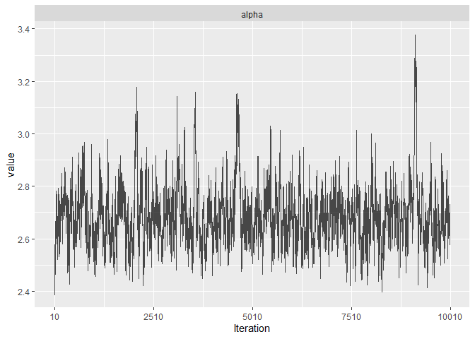

```r
#import ggmcmc library
suppressWarnings(library(ggmcmc))

S <- ggs(as.mcmc(model))

#trace plots
ggs_traceplot(S, family = c("alpha"))
```

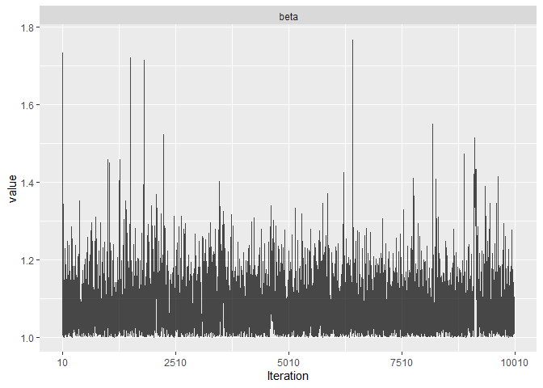

```r
ggs_traceplot(S, family = c("beta"))
```

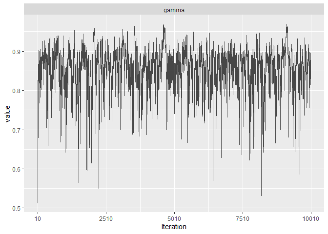

```r
ggs_traceplot(S, family = c("gamma"))
```

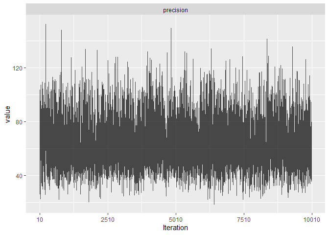

```r
ggs_traceplot(S, family = c("precision"))
```

As it can be noticed, in all four of the plots there is no trend increasing/decreasing with the number of iterations. Instead, there are fluctuations from start to end (that in general could indicate that the chain might have reached the right distribution, i.e. the stationary distribution). The latter plot is by far the best one, it seems to provide the evidence of convergence. However, for the first and the third plot, things are far from being “perfect”, in fact the *mixing* seems to be only marginal, and rather slow, potentially indicating high autocorrelation among the samples.

### 1H)

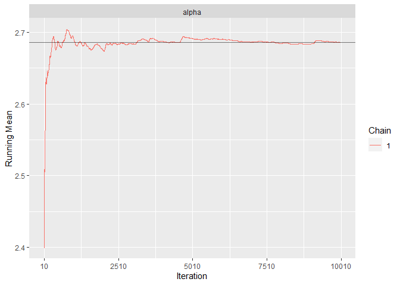

```r
#running means
ggs_running(S, family = c("alpha"))
```

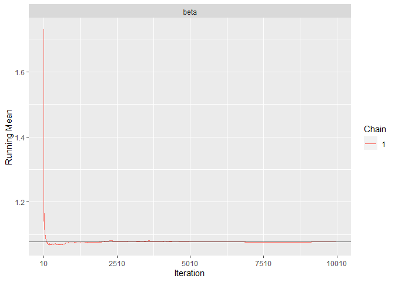

```r
ggs_running(S, family = c("beta"))
```

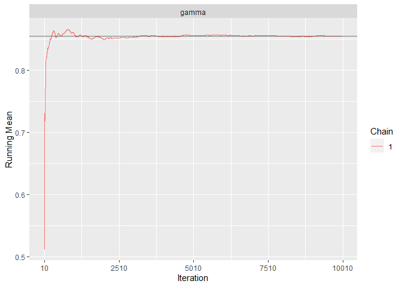

```r
ggs_running(S, family = c("gamma"))
```

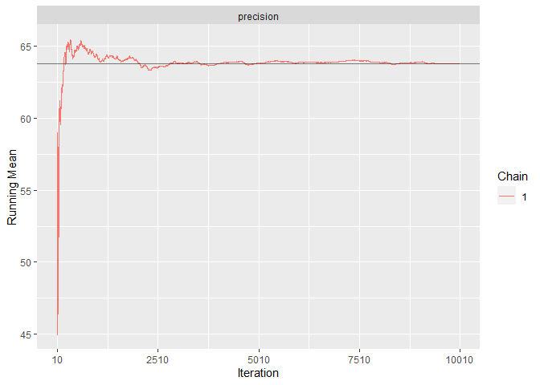

```r
ggs_running(S, family = c("precision"))
```

All the four plots underline a converging behavior for the empirical averages of the parameters, with increasing number of iterations.

### 1I)

```r
alpha.est <- model$BUGSoutput$mean$alpha
beta.est <- model$BUGSoutput$mean$beta
gamma.est <- model$BUGSoutput$mean$gamma
prec.est <- model$BUGSoutput$mean$precision
cat("Empirical Means:\n","alpha est.: ", round(alpha.est, 3), ", ",  "beta est.: ", round(beta.est, 3), ", ", "gamma est.: ", round(gamma.est, 3), ", ", "precision est.: ", round(prec.est, 3), ", ", sep="")
```

```
## Empirical Means:
## alpha est.: 2.686, beta est.: 1.078, gamma est.: 0.855, precision est.: 63.781,
```

```r
suppressWarnings(library(LaplacesDemon))
alpha.ess <- ESS(model$BUGSoutput$sims.array[,1,"alpha"])
beta.ess <- ESS(model$BUGSoutput$sims.array[,1,"beta"])
gamma.ess <- ESS(model$BUGSoutput$sims.array[,1,"gamma"])
prec.ess <- ESS(model$BUGSoutput$sims.array[,1,"precision"])
cat("Effective Sample Sizes:\n","alpha ess.: ", round(alpha.ess, 3), ", ",  "beta ess.: ", round(beta.ess, 3), ", ", "gamma ess.: ", round(gamma.ess, 3), ", ", "precision ess.: ", round(prec.ess, 3), ", ", sep="")
```

```
## Effective Sample Sizes:
## alpha ess.: 235.225, beta ess.: 961.839, gamma ess.: 374.578, precision ess.: 4317.917,
```

```r
# MCMC error (taking autocorrelation into account)
alpha.appr.err <- var(model$BUGSoutput$sims.array[,1,"alpha"])/alpha.ess
beta.appr.err <- var(model$BUGSoutput$sims.array[,1,"beta"])/beta.ess
gamma.appr.err <- var(model$BUGSoutput$sims.array[,1,"gamma"])/gamma.ess
prec.appr.err <- var(model$BUGSoutput$sims.array[,1,"precision"])/prec.ess
cat("alpha approx. error: ", alpha.appr.err, ", ",  "beta approx. error: ", beta.appr.err, ",\n", "gamma approx. error: ", gamma.appr.err, ", ", "precision approx. error: ", prec.appr.err, ", ", sep="")
```

```
## alpha approx. error: 5.774216e-05, beta approx. error: 5.054211e-06,
## gamma approx. error: 7.622748e-06, precision approx. error: 0.06822511,
```

The approximation error would have been simply the $\frac{sample \: var}{n}$ in the i.i.d. case, however in a MCMC it’s computed as the sample variance divided by the effective sample size (ESS), since there is dependecy by construction between samples.

### 1L)

```r
alpha.post.uncert <- model$BUGSoutput$sd$alpha
beta.post.uncert <- model$BUGSoutput$sd$beta
gamma.post.uncert <- model$BUGSoutput$sd$gamma
prec.post.uncert <- model$BUGSoutput$sd$precision

cat("alpha posterior uncertainty: ", round(alpha.post.uncert,3),", ","beta posterior uncertainty: ",round(beta.post.uncert,3),",\n","gamma posterior uncertainty: ",round(gamma.post.uncert,3),", ","precision posterior uncertainty: ",round(prec.post.uncert,3),", ",sep="")
```

```
## alpha posterior uncertainty: 0.117, beta posterior uncertainty: 0.07,
## gamma posterior uncertainty: 0.053, precision posterior uncertainty: 17.164,
```

The parameter having the highest posterior uncertainty in this case is the *precision*. Its value was automatically computed by the JAGS model, and it is basically the standard deviation of the array of simulated values.

```r
#In fact:
sd(model$BUGSoutput$sims.array[,,"precision"])
```

```
## [1] 17.16363
```

### 1M)

```r
corr.matrix <- cor(model$BUGSoutput$sims.array[,,c("alpha","beta","gamma","precision")])
corr.matrix
```

```
##                  alpha       beta      gamma    precision
## alpha      1.000000000  0.2317669  0.8590112 -0.004661426
## beta       0.231766854  1.0000000 -0.1286415 -0.235433176
## gamma      0.859011203 -0.1286415  1.0000000  0.126019706
## precision -0.004661426 -0.2354332  0.1260197  1.000000000
```

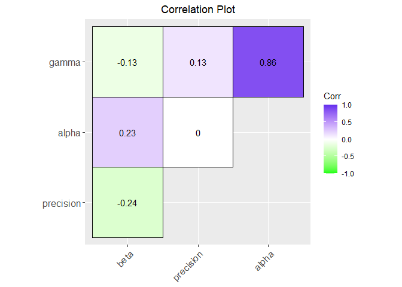

As it can be seen in the correlation-plot above, the pair of parameters having the largest correlation in absolute value are *alpha* and *gamma*. Again, as in the previous point, this value was computed on the array of simulated values of the MCMC.

### 1N)

Starting by defining the model using JAGS language:

```r
model{
        for( i in 1:N ) {
            Y[i] ~ dnorm(mu[i], precision)
            mu[i] <- alpha - beta * pow(gamma,x[i])
        }
      Ypred20 ~ dnorm(condexp20, precision)
        condexp20 <- alpha - beta * pow(gamma,20)
        alpha ~ dnorm(0.0, 1.0E-3)I(1.0,)
        beta ~ dnorm(0.0, 1.0E-3)I(1.0,)
        gamma ~ dbeta(1.0, 1.0)
        precision ~ dgamma(2.5, 0.1125)
    }
```

Then:

```r
model.pred.20 <- jags(data=df, inits=init.values,
                      parameters.to.save=c("alpha","beta","gamma","precision","Ypred20","condexp20"), model.file="dugong_pred_20_model.txt",
                      n.chains=1, n.iter=10000, n.thin=1, n.burnin=10, quiet = T)
model.pred.20
```

[output not shown]

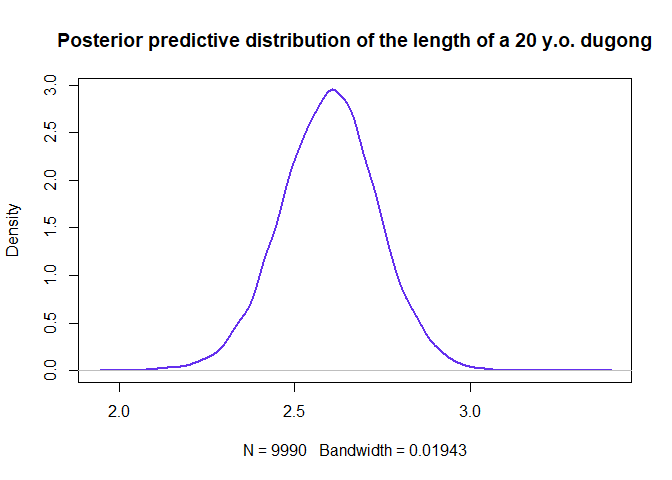

```
## Prediction for the length of a 20 y.o. dugong: 2.599027
```

### 1O)

The model specified in the txt file is now equal to the one of the previous point, with the $x_i$ of the regression equation set equal to 30.

```r
model.pred.30 <- jags(data = df, inits = init.values,
                      parameters.to.save=c("alpha","beta","gamma","precision","Ypred30","condexp30"),
                      model.file="dugong_pred_30_model.txt", n.chains=1, n.iter=10000, n.thin=1,
                      n.burnin=10, quiet = T)
model.pred.30
```

```
## Inference for Bugs model at "dugong_pred_30_model.txt", fit using jags,
##  1 chains, each with 10000 iterations (first 10 discarded)
##  n.sims = 9990 iterations saved
##           mu.vect sd.vect    2.5%     25%     50%     75%   97.5%
## Ypred30     2.648   0.153   2.346   2.547   2.648   2.750   2.946
## alpha       2.674   0.110   2.494   2.597   2.662   2.737   2.921
## beta        1.076   0.067   1.003   1.027   1.059   1.106   1.252
## condexp30   2.649   0.080   2.494   2.593   2.650   2.706   2.801
## gamma       0.849   0.055   0.716   0.821   0.858   0.888   0.930
## precision  63.665  16.738  35.319  51.700  62.123  74.156 100.484
## deviance  -43.962   4.556 -50.940 -47.328 -44.597 -41.266 -33.395
##
## DIC info (using the rule, pD = var(deviance)/2)
## pD = 10.4 and DIC = -33.6
## DIC is an estimate of expected predictive error (lower deviance is better).
```

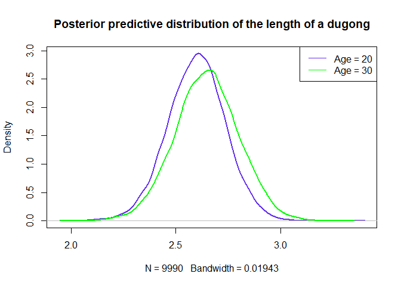

```
## Prediction of length of dugong with age x_i = 30: 2.647932
```

### 1P)

To assess which prediction is less precise, the posterior uncertainty or the size of the equal-tailed credible interval can be compared.

```r
pred.20.sd <- model.pred.20$BUGSoutput$sd$Ypred20
pred.20.ci <- quantile(model.pred.20$BUGSoutput$sims.array[,,"Ypred20"], probs = c(0.025,0.975)) #at 95%

pred.30.sd <- model.pred.30$BUGSoutput$sd$Ypred30
pred.30.ci <- quantile(model.pred.30$BUGSoutput$sims.array[,,"Ypred30"], probs = c(0.025,0.975)) #at 95%
```

```
## Prediction for Age = 20: 2.599
## sd: 0.139, ETI: [2.322, 2.868], ETI size: 0.546
##
## Prediction for Age = 30: 2.648
## sd: 0.153, ETI: [2.346, 2.946], ETI size: 0.599
```

Since the size of the CI is wider for the “age = 30” prediction, it can be concluded that that prediction is less precise with respect to the other one. Moreover, this could have also been suggested by the distribution of the age variable, presenting age = 30 as a potentially more extreme value (keeping in mind although that this is just a possibility since the sample size is very small).

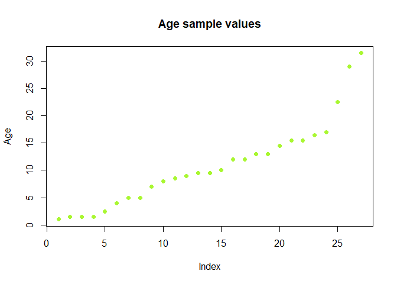

# Exercise 2

## 2A)

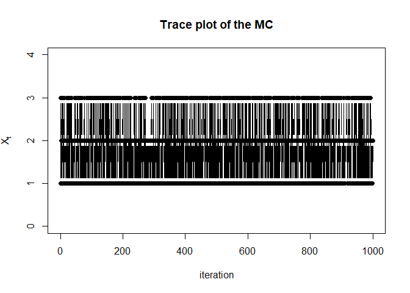

```r
set.seed(42)

# State space
S <- c(1,2,3)

# Transition Probability Matrix
tpm <- matrix(c(0, 1/2, 1/2, 5/8 ,1/8 ,1/4, 2/3, 1/3, 0), nrow = 3, byrow = T)

# Starting state at time 0
x0 <- 1
n.sample <- 1000

# Initialize the chain
chain <- rep(NA, n.sample + 1)

# Set the starting value of the chain
chain[1] <- x0

# MCMC Simulation
for(t in 1:n.sample){
  chain[t+1] <- sample(x = S, size = 1, prob = tpm[chain[t],])
}

#Trace Plot
plot(0:n.sample, chain, ylim=c(0,4), type="b", pch=19, main="Trace plot of the MC",
     xlab="iteration", ylab=expression(X[t]))
```

Also here there is no trend increasing/decreasing with the number of iterations. Instead, there are fluctuations from the beginning to the end.

## 2B)

```r
# Empirical Relative Frequency of the three states
prop.table(table(chain))
```

```
## chain
##         1         2         3
## 0.4005994 0.3336663 0.2657343
```

## 2C)

```r
set.seed(42)
n.sample <- 1000
n.chains <- 500
final.states <- rep(NA, n.chains)

for(c in 1:n.chains){
  for(t in 1:n.sample){
    chain[t+1] <- sample(x = S, size = 1, prob = tpm[chain[t],])
  }

  final.states[c] <-  chain[t+1]
}

# Empirical Relative Frequency of the final states
prop.table(table(final.states))
```

```
## final.states
##     1     2     3
## 0.402 0.292 0.306
```

This simulation approximates the probability of ending up in that state at that time, i.e. in one of the three states after 1000 iterations starting from $X_0 = 1$.

In the previous point instead, the quantity being approximated by the MCMC simulation was the stationary distribution.

## 2D)

Given a Transition Probability Matrix (e.g., P), the stationary distribution $\pi = (\pi_1,\pi_2,\pi_3)^T$ must satisfy the following equation: $P^T \pi = \pi$, or alternatively $\pi$ must be a possible solutions for $(P^T-\lambda I)\pi=0 \;\mid\; \pi_1+\pi_2+\pi_3=1$.

In R this idea is implemented in the following way:

```r
pi <- eigen(t(tpm))$vector[,1]/sum(eigen(t(tpm))$vector[,1])
pi
```

```
## [1] 0.3917526 0.3298969 0.2783505
```

```r
t(tpm)%*%pi #to double-check
```

```
##           [,1]
## [1,] 0.3917526
## [2,] 0.3298969
## [3,] 0.2783505
```

```r
all(round(pi, 7) == round(t(tpm)%*%pi, 7))
```

```
## [1] TRUE
```

```r
#Alternatively..
suppressWarnings(library(expm))
stationary <- tpm %^% 1000
stationary
```

```
##           [,1]      [,2]      [,3]
## [1,] 0.3917526 0.3298969 0.2783505
## [2,] 0.3917526 0.3298969 0.2783505
## [3,] 0.3917526 0.3298969 0.2783505
```

## 2E)

The stationary distribution seems to be approximated better by the empirical relative frequencies of point *2B*, with respect to the ones of point *2C*. However, this was expectable since the latter is approximating a different distribution as explained in that point.

This difference is even more noticeable at larger values of n.sample, in fact:

```r
# Normal One
set.seed(42)
n.sample <- 10000
chain <- rep(NA, n.sample + 1)
chain[1] <- x0
for(t in 1:n.sample){
  chain[t+1] <- sample(x = S, size = 1, prob = tpm[chain[t],])
}
normal <- unname(prop.table(table(chain)))

# Final State
set.seed(42)
n.sample <- 10000
chain <- rep(NA, n.sample + 1)
chain[1] <- x0
n.chains <- 500

for(c in 1:n.chains){
  for(t in 1:n.sample){
    chain[t+1] <- sample(x = S, size = 1, prob = tpm[chain[t],])
  }
  final.states[c] <-  chain[t+1]
}
final <- unname(prop.table(table(final.states)))

cat("Stationary Distribution: ", pi[1], " ", pi[2]," ", pi[3], "\n", "Point '2B' Distribution: ", normal[1], " ", normal[2]," ", normal[3], "\n", "Point '2C' Distribution: ", final[1], "     ", final[2],"      ", final[3], sep="")
```

```
## Stationary Distribution: 0.3917526 0.3298969 0.2783505
## Point '2B' Distribution: 0.3926607 0.3281672 0.2791721
## Point '2C' Distribution: 0.416     0.33      0.254
```

## 2F)

```r
x0 <- 2

# Normal One
set.seed(42)
n.sample <- 1000
chain <- rep(NA, n.sample + 1)
chain[1] <- x0
for(t in 1:n.sample){
  chain[t+1] <- sample(x = S, size = 1, prob = tpm[chain[t],])
}
normal <- unname(prop.table(table(chain)))

# Final State
set.seed(42)
chain <- rep(NA, n.sample + 1)
n.chains <- 500
chain[1] <- x0

for(c in 1:n.chains){
  for(t in 1:n.sample){
    chain[t+1] <- sample(x = S, size = 1, prob = tpm[chain[t],])
  }
  final.states[c] <-  chain[t+1]
}
final <- unname(prop.table(table(final.states)))

cat("Stationary Distribution: ", pi[1], " ", pi[2]," ", pi[3], "\n", "Point '2B' Distribution: ", normal[1], " ", normal[2]," ", normal[3], "\n", "Point '2C' Distribution: ", final[1], "     ", final[2],"     ", final[3], sep="")
```

```
## Stationary Distribution: 0.3917526 0.3298969 0.2783505
## Point '2B' Distribution: 0.3996004 0.3356643 0.2647353
## Point '2C' Distribution: 0.402     0.292     0.306
```

Changing the starting state will apparently leave the empirical relative frequency of the three states unchanged for point *2C*, but it will affect slightly the one of point *2B* (again, it can be expected that at larger values of *n.sample* and towards convergence the starting state will be less and less relevant).